# Leeds Accidents Analysis

Ahmed A. Radhi, Khalid Talal Suliman

3/13/2021

```r
packages <- c("tidyverse", "leaflet","sf")
installed_packages <- packages %in% rownames(installed.packages())
if (any(installed_packages == FALSE)) {
  install.packages(packages[!installed_packages])
}

library(tidyverse)
library(leaflet)
library(sf)
```

# Task 1

```r
# Loading the data into R
Accidents_2017 <- read_csv("Data/datagov-uk-6efe5505-941f-45bf-b576-4c1e09b579a1/2017-8.csv",
col_names = c("Reference_Number","Easting","Northing","Vehicles_Num","Accident_Date","Time","Road_Class","Road_Surface",
              "Lightning_Cond","Weather_Cond","Vehicle_Type","Casualty_Class","Severity","Gender","Age"), skip = 1)
# Parsing the data
Accidents_Date <- Accidents_2017$Accident_Date
Accidents_Date <- parse_date(Accidents_Date, "%m/%d/%Y")

Time <- Accidents_2017$Time
Time <- parse_time(Time, "%H%M")

# Adding the new columns to the tibble.
Accidents_2017 <- Accidents_2017 %>%
  select(1:4, 7:15) %>%
  mutate(Accidents_Date, Time)

Accidents_2017 <- Accidents_2017[,c(1:4,14,15,5:13)]
```

```r
str(Accidents_2017)
```

```
## tibble [2,203 x 15] (S3: tbl_df/tbl/data.frame)
##  $ Reference_Number: chr [1:2203] "3AP0313" "3BE0850" "4110858" "4110858" ...
##  $ Easting         : num [1:2203] 426340 430828 428940 428940 429899 ...
##  $ Northing        : num [1:2203] 428455 433222 429856 429856 434277 ...
##  $ Vehicles_Num    : num [1:2203] 1 2 2 2 2 2 3 3 2 2 ...
##  $ Accidents_Date  : Date[1:2203], format: "2017-03-17" "2017-01-14" ...
##  $ Time            : 'hms' num [1:2203] 08:15:00 13:30:00 08:05:00 08:05:00 ...
##   ..- attr(*, "units")= chr "secs"
##  $ Road_Class      : chr [1:2203] "A643" "A61" "A653" "A653" ...
##  $ Road_Surface    : chr [1:2203] "Dry" "Dry" "Wet/Damp" "Wet/Damp" ...
##  $ Lightning_Cond  : chr [1:2203] "Daylight: Street lights present" "Daylight: Street lights present" "Daylight: Street lights present" "Daylight: Street lights present" ...
##  $ Weather_Cond    : chr [1:2203] "Other" "Fine without high winds" "Fine without high winds" "Fine without high winds" ...
##  $ Vehicle_Type    : chr [1:2203] "Car" "Pedal cycle" "Car" "Car" ...
##  $ Casualty_Class  : chr [1:2203] "Pedestrian" "Driver or rider" "Driver or rider" "Driver or rider" ...
##  $ Severity        : chr [1:2203] "Serious" "Slight" "Slight" "Slight" ...
##  $ Gender          : chr [1:2203] "Female" "Male" "Male" "Male" ...
##  $ Age             : num [1:2203] 61 36 32 30 26 34 39 69 18 17 ...
```

We have 2,203 observations, 15 variables (with `Age` and `Road_Surface` as examples of continuous and categorical variables, respectively), and we have times and dates in the `Accidents_Date` and `Time` variables. This satisfies the data requirements for the MATH 214 project.

## Description

The dataset shows information on road accidents across Leeds during the year 2017.

`Reference_Number` : Reference number of the accident (character)

`Easting` : X-coordinate of the location of the accident using grid coordinates (double)

`Northing` : Y-coordinate of the location of the accident using grid coordinates (double)

`Vehicles_Num` : Number of vehicles involved in the accident (double)

`Time` : Time of the accident (double)

`Road_Class` : Class of road on which the accident happened (character)

`Road_Surface` : Surface of the road during the accident (character)

`Lightning_Cond` : Light conditions during the accident (character)

`Weather_Cond` : Weather conditions during the accident (character)

`Vehicle_Type` : Type of vehicle that caused the accident (character)

`Casualty_Class` : Class of the casualty (character)

`Severity` : Degree of casualty severity (character)

`Gender` : Gender of the casualty (character)

`Age` : Age of the casualty (double)

## Reference

https://data.world/datagov-uk/6efe5505-941f-45bf-b576-4c1e09b579a1

# Task 2

## Questions

1. What are the worst conditions to drive in ?
2. What season has the most accidents ?
3. What is the worst time to drive at ?
4. Which area in Leeds has the most accidents ?
5. Which roads are the most dangerous ?
6. What are the age distributions for the casualty classes ?
7. What characteristics increase the possibility of an accident ?
8. Does the location or road influences the nature of an accident ?
9. Why does the number of accidents increase towards the end of the year ?
10. What do the 2 drops in the Accidents against Time graph represent ?
11. Do accidents increase in the holidays ?

## Variance

### 1. Variance (Age)

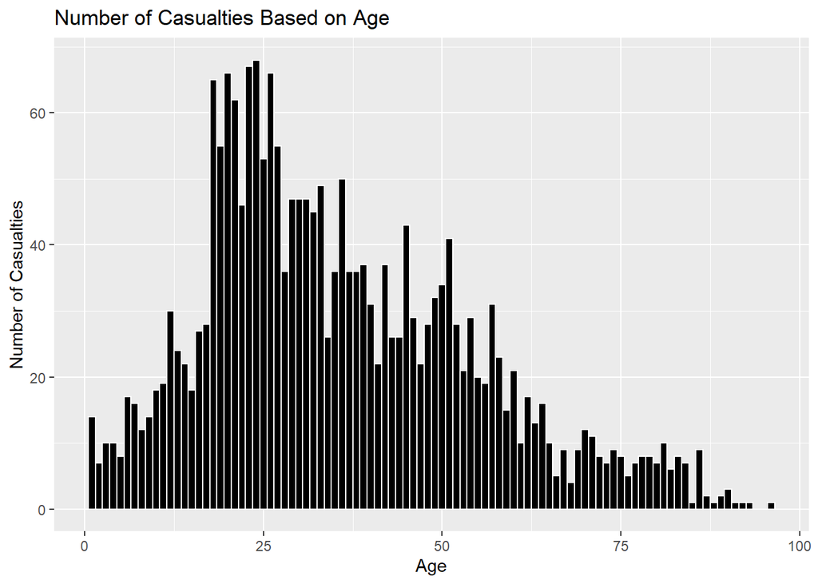

```r
ggplot(data = Accidents_2017, mapping= aes(x=Age)) +
  geom_histogram(binwidth = 1,fill="black", color = "white") +
  ggtitle("Number of Casualties Based on Age") +
  ylab("Number of Casualties")
```

```r
Accidents_2017 %>%
  group_by(Age) %>%
  summarise(count = n())
```

```
## # A tibble: 94 x 2
##      Age count
##  * <dbl> <int>
##  1     1    14
##  2     2     7
##  3     3    10
##  4     4    10
##  5     5     8
##  6     6    17
##  7     7    16
##  8     8    12
##  9     9    14
## 10    10    18
## # ... with 84 more rows
```

#### As the age increase, the number of casualties increases until the age 26. After the age 26 , as the age increases the number of casualties decreases. This was expected as older drivers are more experienced than younger ones. It is important to note that there is a big jump in the number of casualties from age 17 to 18.

### 2. Variance (Gender)

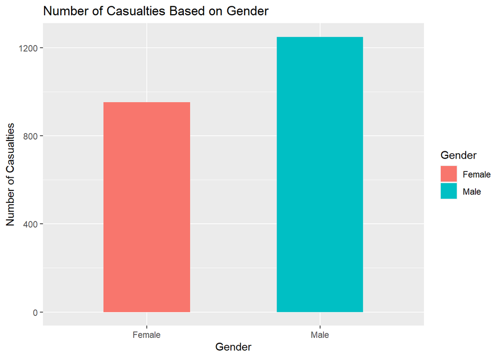

```r
ggplot(data = Accidents_2017, mapping = aes(x=Gender)) +
  geom_bar(aes(fill = Gender) , width = 0.5) +
  ggtitle("Number of Casualties Based on Gender") +
  ylab("Number of Casualties")
```

```r
Accidents_2017 %>%
  group_by(Gender) %>%
  summarise(count = n())
```

```
## # A tibble: 2 x 2
##   Gender count
## * <chr>  <int>
## 1 Female   953
## 2 Male    1250
```

#### Males have a higher tendency to cause accidents. The ratio between males and females in accidents is slightly above 1.3.

### 3. Variance (Number of Accidents Per Month)

```r
# Accidents per day

Accidents_2017 %>%
  group_by(Accidents_Date) %>%
  summarise(sum = n())
```

```
## # A tibble: 360 x 2
##    Accidents_Date   sum
##  * <date>         <int>
##  1 2017-01-01         4
##  2 2017-01-02         7
##  3 2017-01-03         3
##  4 2017-01-04         7
##  5 2017-01-05         4
##  6 2017-01-06         5
##  7 2017-01-07         5
##  8 2017-01-09         5
##  9 2017-01-10         9
## 10 2017-01-11         7
## # ... with 350 more rows
```

```r
# Accidents per month

( Accidents_by_month <-
    Accidents_2017 %>%
    mutate(month = format(Accidents_Date,"%m")) %>%
    group_by(month) %>%
    summarise(accidents_num = n())
)
```

```
## # A tibble: 12 x 2
##    month accidents_num
##  * <chr>         <int>
##  1 01              199
##  2 02              157
##  3 03              174
##  4 04              173
##  5 05              162
##  6 06              167
##  7 07              177
##  8 08              164
##  9 09              182
## 10 10              223
## 11 11              234
## 12 12              191
```

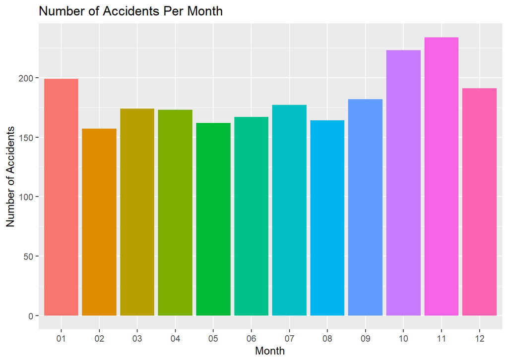

```r
# Plot of Accidents per month
ggplot(data = Accidents_by_month, mapping = aes(x = month, y = accidents_num)) +
  geom_bar(aes(fill = month) , show.legend = F, stat = "identity") +
  ggtitle("Number of Accidents Per Month") +
  xlab("Month") +
  ylab("Number of Accidents")
```

#### Throughout the year, there were at least 150 accidents every month. February was the month with the least number of accidents, a reason for this is that February 2017 had only 28 days. On the other hand, November had the highest number of accidents (234). Towards the end of the year, the number of accidents in Leeds increases.

### 4. Variance (Road Surface)

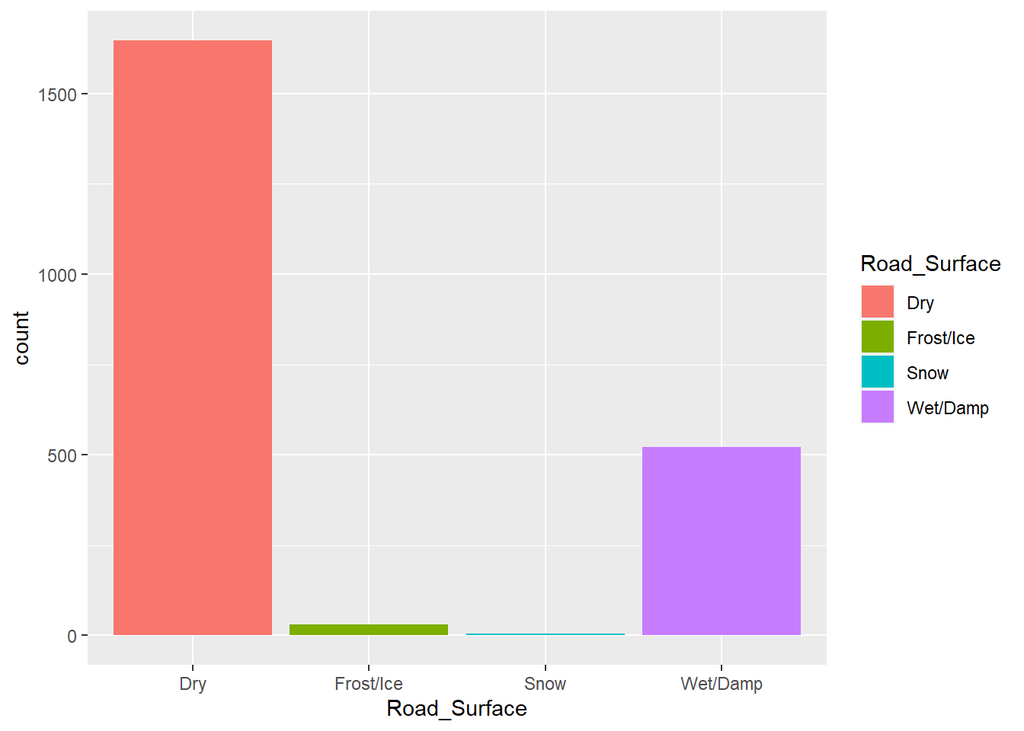

```r
ggplot(data = Accidents_2017) +
  geom_bar(mapping = aes(x = Road_Surface,fill = Road_Surface))
```

```r
Accidents_2017 %>%
  group_by(Road_Surface) %>%
  summarise(count = n())
```

```
## # A tibble: 4 x 2
##   Road_Surface count
## * <chr>        <int>
## 1 Dry           1647
## 2 Frost/Ice       30
## 3 Snow             5
## 4 Wet/Damp       521
```

#### Most accidents happen when the road is dry, which is expected as drivers take more care when the road is bad. On average, Leeds has 175.4 rainfall days and 10.6 snowfalls days per year so for the remaining days the road is dry. Thus, number of accidents per day for each climate is 2.97 when it is raining, 3.3 when it is snowing and 9.2 when the climate is dry. The number of accidents per day when the weather is dry is extremely high, and this shows how careless Leeds’ drivers are when the road surface is dry.

### 5. Variance (Time)

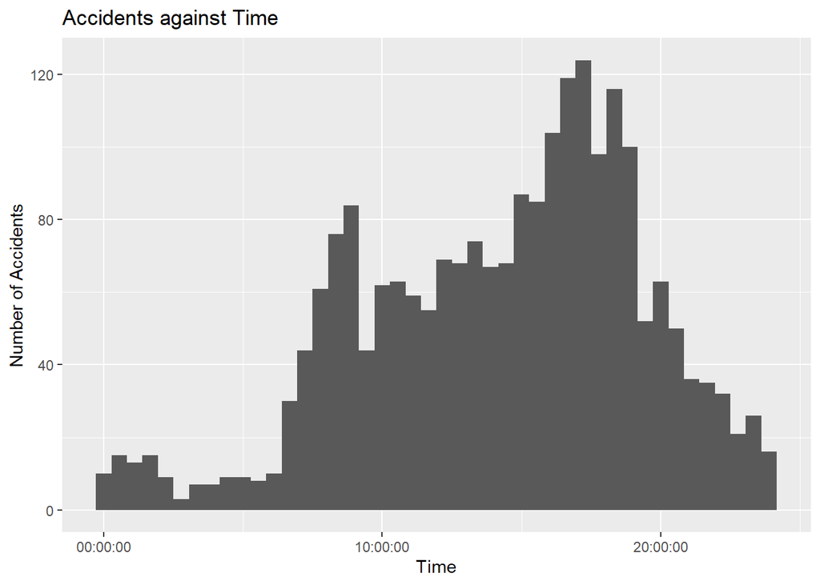

```r
ggplot(Accidents_2017,mapping=aes(x=Time))+
  geom_histogram(binwidth = 2000)+
  ggtitle("Accidents against Time")+
  ylab("Number of Accidents")+
  xlab("Time")
```

#### From 12 am till 6 am the number of accidents is remarkably low. After 6 am, the number of accidents keeps increasing till 5.30 pm. After that, the number of accidents keep decreasing. It is noteworthy to mention that there are 2 big drops in the number of accidents which could represent something.

## Covariance

### 1. Covariance (Age against Count, Classified by Gender)

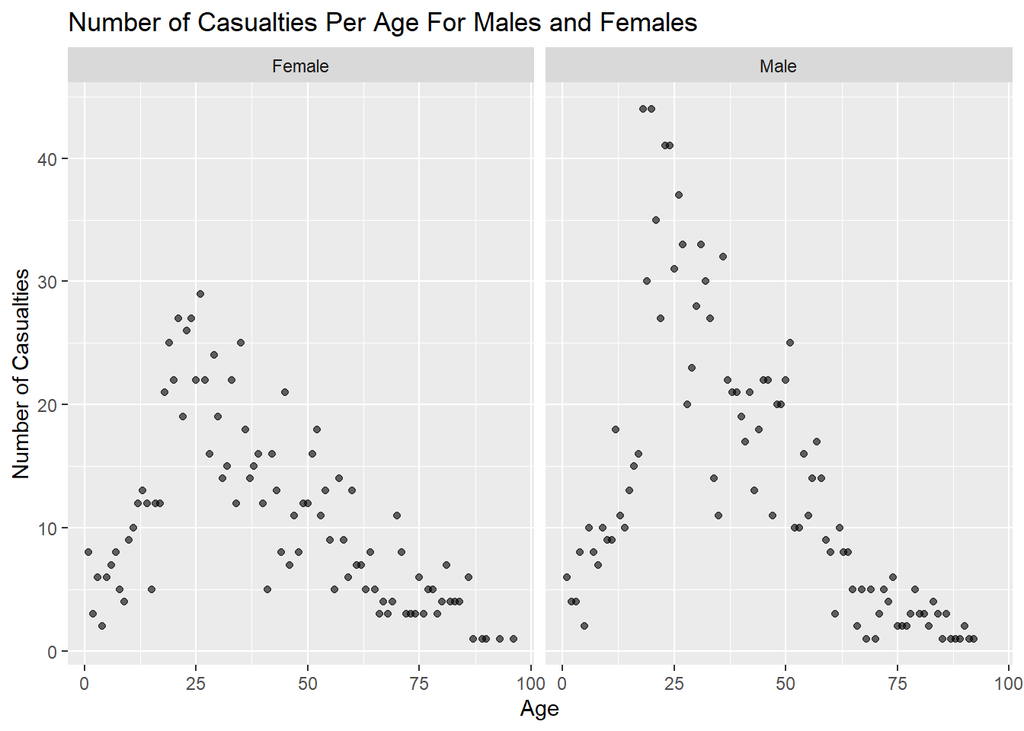

```r
Accidents_2017 %>%
  group_by(Gender, Age) %>%
  summarise(Count = n() ) %>%
  ungroup() %>%
  ggplot(mapping = aes(x=Age , y = Count)) +
  geom_point(alpha = 0.6) +
  facet_wrap(~Gender) +
  ggtitle("Number of Casualties Per Age For Males and Females") +
  ylab("Number of Casualties")
```

```r
Accidents_2017 %>%
  group_by(Gender, Age) %>%
  summarise(Count = n() )
```

```
## # A tibble: 182 x 3
## # Groups:   Gender [2]
##    Gender   Age Count
##    <chr>  <dbl> <int>
##  1 Female     1     8
##  2 Female     2     3
##  3 Female     3     6
##  4 Female     4     2
##  5 Female     5     6
##  6 Female     6     7
##  7 Female     7     8
##  8 Female     8     5
##  9 Female     9     4
## 10 Female    10     9
## # ... with 172 more rows
```

#### For females, as the age increases the count increases. The count peaks around the mid-20s,then the count declines gradually. The males’ graph has a similar shape as females’. The only difference is that the males’ graph has a higher peak and the drop is sharper.

### 2. Covariance (Time and Severity)

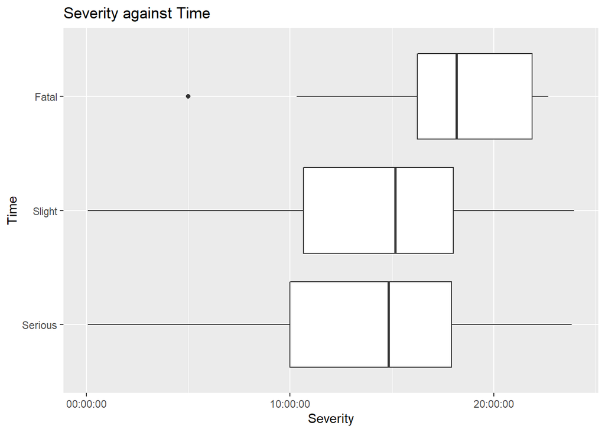

```r
ggplot(data = Accidents_2017)+
  geom_boxplot(mapping = aes(x = reorder(Severity, Time, FUN = median), y = Time))+ coord_flip()+
  ggtitle("Severity against Time")+
  ylab("Severity")+
  xlab("Time")
```

### 3. Covariance (Age and Severity)

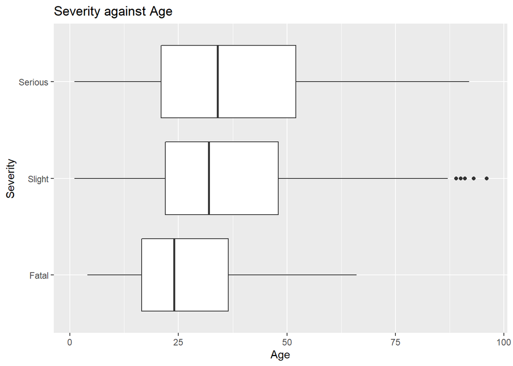

```r
ggplot(data = Accidents_2017)+
  geom_boxplot(mapping = aes(x = reorder(Severity, Age, FUN = median), y = Age))+ coord_flip()+
  ggtitle("Severity against Age")+
  ylab("Age")+
  xlab("Severity")
```

#### Fatal accidents tend to happen to people under the age of 25 more frequently. Slight accidents have a few outliers. Serious accidents have the widest inter-quartile range.

### 4. Covariance (Age against Count, Classified by Casualty Class)

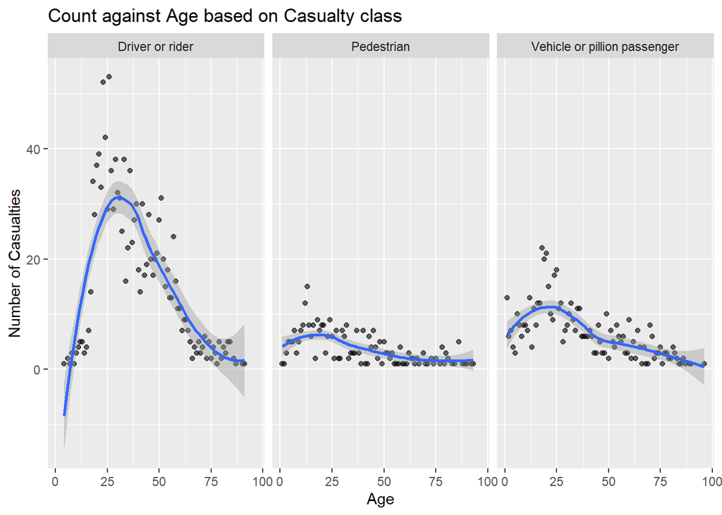

```r
Accidents_2017 %>%
  group_by(Casualty_Class, Age) %>%
  summarise(Count = n() ) %>%
  ungroup() %>%
  ggplot(mapping = aes(x=Age , y = Count)) +
  geom_point(alpha = 0.6) +
  geom_smooth()+
  facet_wrap(~Casualty_Class) +
  ggtitle("Count against Age based on Casualty class") +
  ylab("Number of Casualties")
```

```r
Accidents_2017 %>%
  group_by(Casualty_Class,Age) %>%
  summarise(Count = n() )
```

```
## # A tibble: 260 x 3
## # Groups:   Casualty_Class [3]
##    Casualty_Class    Age Count
##    <chr>           <dbl> <int>
##  1 Driver or rider     4     1
##  2 Driver or rider     6     2
##  3 Driver or rider     7     1
##  4 Driver or rider     8     3
##  5 Driver or rider     9     1
##  6 Driver or rider    10     3
##  7 Driver or rider    11     4
##  8 Driver or rider    12     5
##  9 Driver or rider    13     5
## 10 Driver or rider    14     3
## # ... with 250 more rows
```

```r
Accidents_2017 %>%
  group_by(Casualty_Class) %>%
  summarise(Count = n() )
```

```
## # A tibble: 3 x 2
##   Casualty_Class               Count
## * <chr>                        <int>
## 1 Driver or rider               1296
## 2 Pedestrian                     321
## 3 Vehicle or pillion passenger   586
```

#### When the casualty is a driver or rider, as the age increases till the mid-30s the count increases rapidly, then the count falls again. The plots for pedestrains and passengers are very similar. The only disparity is that the passengers have a higher peak. It should be highlighted that the number of casualties between the age 20 till mid-50s is awfully high when the casualty is a driver or rider compared to other casualty classes. Moreover, in the pedestrains’ and passengers’ plots, teenagers have a higher number of casaulties than other age groups. Finally, the number of infants and children casualties is dreadfully high when they are passengers in comparison to other casualty classes.

## Extra Plot:

### Locations of the Accidents

```r
long_lat <- Accidents_2017 %>%
  st_as_sf(coords = c("Easting", "Northing"), crs = 27700) %>%
  st_transform(4326) %>%
  st_coordinates() %>%
  as_tibble()

long_lat_FULL <- Accidents_2017 %>%
  mutate(long_lat)  %>%
  select(Reference_Number, X, Y, Severity)

pal <- colorFactor(c("yellow", "orange", "red"), domain = c("Slight", "Serious", "Fatal"))

leaflet(data = long_lat_FULL)%>%
  addTiles() %>%
  addCircleMarkers(lng = ~X, lat = ~Y,
                   color = ~pal(Severity),
                   stroke = F, fillOpacity = 0.75,
                   clusterOptions = markerClusterOptions())  %>%
  addLegend(colors = c("yellow", "orange", "red") , labels = c("Slight", "Serious", "Fatal"), title = "Severity")
```

[interactive chart not shown]

#### The map divides the locations where the accidents took place into clusters, which helps knowing where the highest number of accidents took place. Also, the map classifies each accident on the map based on the severity.